# Assigning Generalized Horizon Labels

D.E. Beaudette

Wednesday, September 24, 2014

# Using Generalized Horizon Labels

D.E. Beaudette, J.M. Skovlin  
2015-12-18  
This document is based on `aqp` version 1.9.3 and `soilDB` version 1.6.7.

# Introduction

## An Example

# Setup R Envionment

If you have never used the aqp or [soildb](https://r-forge.r-project.org/scm/viewvc.php/*checkout*/docs/soilDB/soilDB-Intro.html?root=aqp) packages before, you will likely need to install them. This only needs to be done once.

```r
# stable version from CRAN + dependencies
install.packages('ape', dep=TRUE)
install.packages('latticeExtra', dep=TRUE)
install.packages('plyr', dep=TRUE)
install.packages('aqp', dep=TRUE)
install.packages('soilDB', dep=TRUE)
# latest versions from R-Forge:
install.packages('aqp', repos="http://R-Forge.R-project.org", type='source')
install.packages('soilDB', repos="http://R-Forge.R-project.org", type='source')
```

Now that you have all of the R packages that this document depends on, it would be a good idea to load them. R packages must be **installed** anytime you change versions of R (e.g. after an upgrade), and **loaded** anytime you want to access functions from within those packages.

```r
library(aqp)
library(soilDB)
library(ape)
library(latticeExtra)
library(plyr)
library(lattice)
library(cluster)
library(MASS)
```

# Sample Data

While the methods outlined in this document can be applied to any collection of pedons, it is convenient to work with a standardized set of data. You can follow along with the analysis by copying code from the following blocks and running it in your **R** session. The sample data used in this document is based on 30 soil profiles that have been correlated to the [Loafercreek](https://soilseries.sc.egov.usda.gov/OSD_Docs/L/LOAFERCREEK.html) soil series from the Sierra Nevada Foothill Region of California. Note that the internal structure of the `loafercreek` data is identical to the structure returned by [`fetchNASIS()` from the soilDB package](https://r-forge.r-project.org/scm/viewvc.php/*checkout*/docs/soilDB/soilDB-Intro.html?root=aqp). All horizon-level values are pulled from the pedon horizon table of the pedons being analyzed.

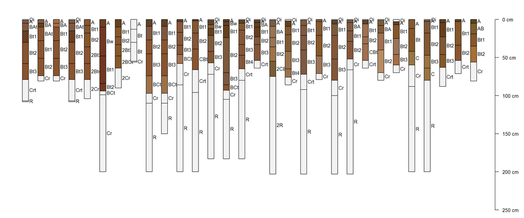

```r
# load sample data from the soilDB package
data(loafercreek, package = 'soilDB')
# keep only the first 30 pedons
pedons <- loafercreek[1:30, ]
# plot profile sketches
par(mar=c(0,0,0,0))
plot(pedons, name='hzname', print.id=FALSE, cex.names=0.8, axis.line.offset=-4)
```

## Optional: Follow Along with Your Data

The following code block demonstrates how to pull data in using the [`fetchNASIS()` function from the soilDB package](https://r-forge.r-project.org/scm/viewvc.php/*checkout*/docs/soilDB/soilDB-Intro.html?root=aqp).

```r
# first load the desired data set within NASIS into your NASIS selected set
# then load data from the NASIS selected set into R
pedons <- fetchNASIS()
# optionally subset the data by taxon name - enter your taxon name
pedons <- pedons[grep(pattern='ENTER_YOUR_TAXON_NAME', f$taxonname, ignore.case=TRUE), ]
```

## A Quick Note on Quantiles and Box-Whisker Plots

[Quantiles (also called percentiles)](http://en.wikipedia.org/wiki/Quantile) are a convenient way to express where a number lies within a distribution. For example, the 5th-percentile of a set of numbers is the value that splits the lowest 5% of the data from the rest. The 50th-percentile, commonly referred to as the median, splits the data exactly in half and is a good alternative to the mean for summarizing central tendency. The 25th and 75th percentiles or 5th and 95th percentiles form useful brackets around the spread around the median. A [box and whisker plot](http://en.wikipedia.org/wiki/Box_plot) uses quantiles to display the central tendency, spread, and balance of a distribution. Unlike the mean and standard deviation, quantiles offer a relatively robust (outliers, distribution shape, skewness, etc.) definition of central tendency (RV) and spread (LOW, HIGH).

The following R code demonstrates the relationship between frequency distribution, quantiles, and box-whisker plot for a set of 500 normally-distributed values with a mean of 10 and standard deviation of 2.

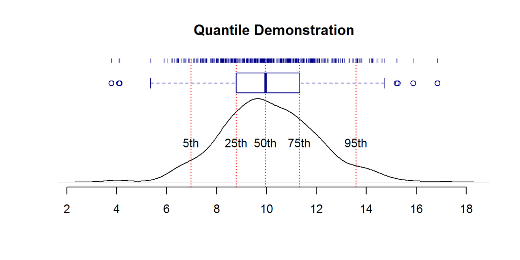

```r
# simulate 500 values from the normal distribution: with mean = 10, sd= 2
set.seed(1010101)
x <- rnorm(n=500, mean=10, sd=2)

# compute the 5th, 25th, 50th, 75th, and 95th percentiles of x
q <- quantile(x, probs=c(0.05, 0.25, 0.5, 0.75, 0.95))

# plot a smoothed frequency distribution
plot(density(x), main='Quantile Demonstration', ylim=c(0, 0.3), ylab='', xlab='', axes=FALSE)

# mark quantiles we computed above
abline(v=q, lty=3, col='red')
text(x=q, y=0.1, labels=c('5th', '25th', '50th', '75th', '95th'))

# overlay a box-whisker plot
boxplot(x, at=0.25, add=TRUE, horizontal=TRUE, boxwex=0.1, border='DarkBlue', axes=FALSE)

# overlay lines at the original values
rug(x, side=3, col='DarkBlue')

# add x-axis
axis(side=1, at=pretty(x))
```

# Methods

## Assignment of Generalized Horizon Labels

Once a set of generalized horizon labels have been determined a corresponding set of [regular expression](http://en.wikipedia.org/wiki/Regular_expression) (REGEX) rules were developed to convert field-described designations into GHL. Pattern matching with REGEX will typically assign useful GHL, however, there will always be cases where manual intervention is required. More on that later.

```r
# save our GHL
n <- c('A','Bt1','Bt2','Bt3','Cr','R')
# REGEX rules
p <- c('^A$|Ad|Ap',
       'Bt1$',
       '^Bt2$',
       '^Bt3|^Bt4|CBt$|BCt$|2Bt|2CB$|^C$',
       'Cr',
       'R')
```

Apply GHL pattern-matching rules and save to a new column called `genhz` and cross-tabulate the occurrence of GHL and original designations.

```r
pedons$genhz <- generalize.hz(pedons$hzname, n, p)
# cross-tabulate original horizon designations and GHL
addmargins(table(pedons$genhz, pedons$hzname))
```

```
##
##            2BCt 2Bt3 2Bt4 2CB 2Cr  2R   A  AB  BA BAt BCt  Bt Bt1 Bt2 Bt3 Bt4  Bw   C CBt  Cr Crt
##   A           0    0    0   0   0   0  30   0   0   0   0   0   0   0   0   0   0   0   0   0   0
##   Bt1         0    0    0   0   0   0   0   0   0   0   0   0  28   0   0   0   0   0   0   0   0
##   Bt2         0    0    0   0   0   0   0   0   0   0   0   0   0  28   0   0   0   0   0   0   0
##   Bt3         1    2    1   1   0   0   0   0   0   0   5   0   0   0  17   2   0   2   2   0   0
##   Cr          0    0    0   0   2   0   0   0   0   0   0   0   0   0   0   0   0   0   0  17   9
##   R           0    0    0   0   0   1   0   0   0   0   0   0   0   0   0   0   0   0   0   0   0
##   not-used    0    0    0   0   0   0   0   1   6   3   0   3   0   0   0   0   3   0   0   0   0
##   Sum         1    2    1   1   2   1  30   1   6   3   5   3  28  28  17   2   3   2   2  17   9
##
##             Oi   R Sum
##   A          0   0  30
##   Bt1        0   0  28
##   Bt2        0   0  28
##   Bt3        0   0  33
##   Cr         0   0  28
##   R          0  14  15
##   not-used  14   0  30
##   Sum       14  14 192
```

## Range in Characteristics by Generalized Horizon Label

## Aggregate Representation of Horizon Depths

## From Typical Pedon to Prototype Pedon